# 1. Import Data

# Pickle the Model

```python
import pickle


Best_model = trained_smote_early_stop
file = 'Best_model.pkl'
fileobj = open(file, 'wb')
pickle.dump(trained_smote_early_stop, fileobj)
fileobj.close()
```

```
INFO:tensorflow:Assets written to: ram://dbee3f93-4e2c-4fed-aaa3-ab1d958e0f70/assets
```

```python
file = 'Best_model.pkl'
fileobj = open(file,'rb')
Best_model = pickle.load(fileobj)
print (Best_model)
```

```
<keras.callbacks.History object at 0x7fbd80e78280>
```

### CONCLUSION AND IMPROVISATION

#### The data was highly biased, which can lead to bad predictor for minority

#### There were no missing points in the data.

#### There were many outliers in a few parameters (Parameter 4:155).

# **PART 2**

## Importing the libraries

```python
import pandas as pd
import numpy as np
import matplotlib.pyplot as plt
import tensorflow
from tensorflow.keras.layers import Flatten, Dense
import seaborn as sns
import random
random.seed(1)
import warnings
warnings.filterwarnings('ignore')
from sklearn.model_selection import train_test_split
import h5py
from tensorflow.keras.utils import to_categorical
from tensorflow.keras.models import Sequential
from tensorflow.keras.layers import Dropout
from tensorflow.keras import regularizers, optimizers
```

# 1. Import the data

```python
data =h5py.File("Part - 4 - Autonomous_Vehicles_SVHN_single_grey1.h5",'r')
```

# 2. Data visualisation and Pre processing

```python
data.keys()
```

```
<KeysViewHDF5 ['X_test', 'X_train', 'X_val', 'y_test', 'y_train', 'y_val']>
```

#### Naming the variables, Creating test, train, and validation data.

```python
X_train=data['X_train']
X_test=data['X_test']
X_val=data['X_val']
y_train=data['y_train']
y_test=data['y_test']
y_val=data['y_val']
```

#### Visualising a chunk of data

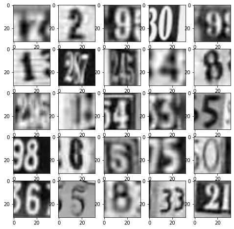

```python
w=10
h=10
fig = plt.figure(figsize=(8,8))
columns = 5
rows = 5

for i in range(1, columns*rows+1):
    img = X_test[i]
    fig.add_subplot(rows, columns,i)
    plt.imshow(img, cmap='gray')
plt.show()
```

#### We can see that the data consist of images with numbers.

```python
print(X_train.shape, X_test.shape, X_val.shape)
```

```
(42000, 32, 32) (18000, 32, 32) (60000, 32, 32)
```

#### We have 42000 variables in train, 18000 in test, and 60,000 in validation data.

```python
print(y_train.shape, y_test.shape, y_val.shape)
```

```
(42000,) (18000,) (60000,)
```

#### We have equal labels for images too.

### let's try to build a basic image classifier and predict some image labels.

```python
n= 40000
x_tr = []

for i in range(n):
    x_tr.append(X_train[i,:].flatten())
x_te = []
for i in range(16000):
    x_te.append(X_test[i,:].flatten())
```

```python
class NN:
    def __init__(self):
        pass

    def train(self, X, y):
        self.tr_x = X
        self.tr_y = y

    def predict (self, x):
        mix_idx = None
        min_dist= 100000

        for test_sample in range (len(self.tr_x)):
            dist = 0
            for each_value in range (len(self.tr_x[0])):
                dist+= abs(float((self.tr_x[test_sample][each_value] - x[each_value])))
            if dist<min_dist:
                min_dist=dist
                min_idx = test_sample
        return self.tr_y[min_idx]
```

```python
classifier = NN()
```

```python
classifier.train(x_tr, y_train)
```

```python
X_test[3].shape
```

```
(32, 32)
```

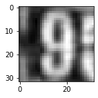

```
9
```

```python
plt.figure(figsize=(2,2))
plt.imshow(X_test[3], cmap = 'gray')
plt.show()
print (classifier.predict(x_te[3]))
```

```python
y_test[3]
```

```
9
```

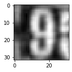

```
9
```

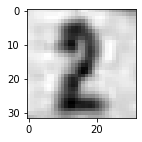

```
6
```

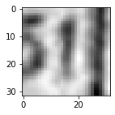

```
5
```

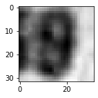

```
6
```

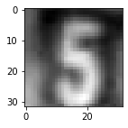

```
9
```

```python
plt.figure(figsize=(2,2))
plt.imshow(X_test[3],cmap="gray")
plt.show()
print(classifier.predict(x_te[3]))
plt.figure(figsize=(2,2))
plt.imshow(X_test[2],cmap="gray")
plt.show()
print(classifier.predict(x_te[2]))
plt.figure(figsize=(2,2))
plt.imshow(X_test[33],cmap="gray")
plt.show()
print(classifier.predict(x_te[33]))
plt.figure(figsize=(2,2))
plt.imshow(X_test[59],cmap="gray")
plt.show()
print(classifier.predict(x_te[59]))
plt.figure(figsize=(2,2))
plt.imshow(X_test[36],cmap="gray")
plt.show()
print(classifier.predict(x_te[36]))
```

#### We can see that the classifier is showing some labels correctly, while missing on some.\

## Building a Deep Neural Network model for this

```python
print (X_train.shape, X_test.shape)
print (y_train.shape, y_test.shape)
```

```
(42000, 32, 32) (18000, 32, 32)
(42000,) (18000,)
```

#### Reshaping data

```python
X_train1=np.array(data['X_train'])
X_test1=np.array(data['X_test'])
X_val1=np.array(data['X_val'])
y_train1=np.array(data['y_train'])
y_test1=np.array(data['y_test'])
y_val1=np.array(data['y_val'])
```

```python
X_train2 = X_train1.reshape(X_train1.shape[0],32,32,1)
X_test2 = X_test1.reshape(X_test1.shape[0],32,32,1)
X_val2 = X_val1.reshape(X_val1.shape[0],32,32,1)
```

```python
X_train2.shape
```

```
(42000, 32, 32, 1)
```

```python
y_train2 = to_categorical(y_train, num_classes=10)
y_test2 = to_categorical(y_test, num_classes=10)
y_val2 = to_categorical(y_val, num_classes=10)
```

## Building a Sequential model

```python
model = Sequential()
model.add (Flatten())
model.add (tensorflow.keras.layers.BatchNormalization())
model.add (Dense(128, activation = 'relu'))
model.add (Dense(10, activation = 'softmax'))
```

```python
model.compile(loss='categorical_crossentropy', metrics=['accuracy'], optimizer= 'sgd')
```

```python
NNmodel = model.fit(X_train2, y_train2, batch_size=32, epochs=50, validation_data=(X_test2, y_test2))
```

[output not shown]

#### With this model we are able to acheive loss: 0.4319 - accuracy: 0.8668 - val_loss: 0.5676 - val_accuracy: 0.8518

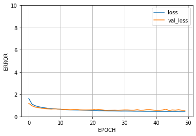

```python
plot_loss(NNmodel)
```

#### The initial loss is not that high, which platues after nearly 10 epochs

```python
model.evaluate(X_val2, y_val2)
```

```
[0.3741317093372345, 0.8949666619300842]
```

#### We are getting similar results on validation set also.

### Experimenting by Creating model with different hyper-parameters

```python
X_train3 = X_train1.reshape(42000,1024)
X_test3 = X_test1.reshape(18000,1024)
X_val3 = X_val1.reshape(60000,1024)
```

```python
print(X_train.shape, X_test.shape)
print(y_train.shape, y_test.shape)
print(X_val.shape, y_val.shape)
```

```
(42000, 32, 32) (18000, 32, 32)
(42000,) (18000,)
(60000, 32, 32) (60000,)
```

```python
def train_and_test_loop(iterations, lr, Lambda, verb=True):

    iterations = iterations
    learning_rate = lr
    hidden_nodes = 256
    output_nodes = 10

    model = Sequential()
    model.add(Dense(hidden_nodes, activation='relu'))
    model.add(Dense(hidden_nodes, activation='relu'))
    model.add(Dense(output_nodes, activation='softmax', kernel_regularizer=regularizers.l2(Lambda)))

    sgd = optimizers.SGD(lr=learning_rate, decay=1e-6, momentum=0.9)
    model.compile(loss='categorical_crossentropy', optimizer=sgd, metrics=['accuracy'])

    model.fit(X_train3, y_train2, epochs=iterations, batch_size=20, verbose= 1)
```

```python
lr = 0.00001
Lambda = 0
train_and_test_loop(1, lr, Lambda)
```

[output not shown]

```python
import math
for k in range(1,10):
    lr = math.pow(10, np.random.uniform(-7.0, 3.0))
    Lambda = math.pow(10, np.random.uniform(-7,-2))
    best_acc = train_and_test_loop(10, lr, Lambda, False)
    print("Try {0}/{1}: Best_val_acc: {2}, lr: {3}, Lambda: {4}\n".format(k, 100, best_acc, lr, Lambda))
```

```
Try 1/100: Best_val_acc: None, lr: 1.5891385098595927e-07, Lambda: 0.0027581302546978996

Try 2/100: Best_val_acc: None, lr: 0.4044695480191106, Lambda: 0.0003432837034934961

Try 3/100: Best_val_acc: None, lr: 3.511147407311695e-05, Lambda: 0.0003976868756621686

Try 4/100: Best_val_acc: None, lr: 0.0004957810964810525, Lambda: 2.9320553516038767e-06

Try 5/100: Best_val_acc: None, lr: 5.901096380310104, Lambda: 0.005115650992501619

Try 6/100: Best_val_acc: None, lr: 0.0811901492485464, Lambda: 0.005147346272760474

Try 7/100: Best_val_acc: None, lr: 0.09748567140136465, Lambda: 7.930201888472897e-07

Try 8/100: Best_val_acc: None, lr: 9.179542971181127e-05, Lambda: 0.0010247756363916487

Try 9/100: Best_val_acc: None, lr: 2.9988945555313514e-06, Lambda: 4.778290003916162e-07
```

## After Trying several techniques, parameters, and models we can conclude that NNModel is giving satisfactory results with

### loss: 0.4319 - accuracy: 0.8668 - val_loss: 0.5676 - val_accuracy: 0.8518

#### We experimented quite a few things for this model, and results varied accordingly.